# Football Players Salaries

Prob. & Statistical Inference - MATH9102

Author

A00046290 - Ignacio Alarcon Varela

Importing Libraries

```r
# Loading all libraries
quiet_library <- function(pkg) {
  suppressMessages(suppressWarnings({
    if (!requireNamespace(pkg, quietly = TRUE)) {
      install.packages(pkg, quiet = TRUE)
    }
    library(pkg, character.only = TRUE)
  }))
}
quiet_library("tidyverse")
# Collection of R packages (dplyr, ggplot2, tidyr, etc.) for data wrangling, visualization, and analysis

quiet_library("pastecs")
# Tools for descriptive statistics, time series analysis, and data exploration (e.g., stat.desc)

quiet_library("psych")   # Descriptive statistics by group

quiet_library("FSA")
# Includes general tools for data analysis (e.g., nonparametric tests, bootstrapping)

quiet_library("semTools")
# Supplementary functions for Structural Equation Modeling (SEM), including model fit, reliability, and measurement invariance tests

quiet_library("VIM") # Visualization and Imputation of Missing Values

quiet_library("naniar") #(naniar short for NA + naniar) - Missing data wrangling plus Little's test

quiet_library("simputation") # For imputing variables
quiet_library("sjstats")  # Provides convenient functions for effect sizes

quiet_library("gmodels")  # Includes 'CrossTable()' for contingency tables.

quiet_library("car")   # Includes Levene's test for homogeneity
quiet_library("effectsize")  # Effect size calculations (Cohen’s d, η², Cramer’s V, etc.)
quiet_library("rstatix")     # Easy-to-use t-tests, ANOVA, nonparametric tests, post-hoc, etc.

quiet_library("gridExtra") # To arrange visualizations.
quiet_library("gtsummary") # Formatting tables
quiet_library("flextable") # Formatting tables
```

Setup for dataset

```r
# datalocation <- file.path("C:","Users", "deirdre.lawless", "downloads") # in case you might want to run

# Folder Direction
datalocation <- file.path("/Users/ignacioalarconvarela/developer/CA-Statistics")
datapath <- file.path(datalocation, "raw_wages.csv")
wages <- read.csv("raw_wages.csv", header = TRUE)
colnames(wages) <- tolower(colnames(wages)) #Setting the column names to be in the Dataset

wages_cleaned <- readRDS("wages_cleaned.rds") #cleaned dataset to be able to render
```

## 1. Introduction

Professional football presents one of the most unequal wage structures in sport, with a small number of elite players earning disproportionately higher salaries. This report analyses data from a large public dataset (Yash, 2024) compiled from the *Football Manager* database, which contains realistic, web-scraped information on over 40,000 players worldwide. The dataset includes variables such as player age, nationality, EU status, league, total appearances, national caps, current reputation, salary and many more.

The purpose of this analysis is to examine how player performance and demographic factors relate to salary levels in professional football. Specifically, the study investigates whether indicators of skill and experience like reputation, appearances, or international exposure are statistically associated with salary, and whether meaningful pay differences exist between European and non European players or across competitive leagues.

To address these aims, four hypotheses were developed (see Table 1). Each hypothesis explores a specific type of relationship, enabling the application of different inferential tests based on variable type and distribution.

**Table 1. Research Hypotheses for Planned Analysis**

| **Analysis Focus** | **Null Hypothesis (H₀)** | **Alternative Hypothesis (H₁)** |
| --- | --- | --- |
| **Current Reputation and Salary** | A player’s current reputation is **not related** to their salary. | A player’s current reputation is **positively related** to their salary. |
| **EU Status and Salary** | Being an EU player **does not affect** a player’s salary. | Being an EU player **does affect** a player’s salary. |
| **League and Salary** | Average salaries **are not different** across football leagues. | Average salaries **are different** across football leagues. |
| **EU Status and League** | EU status and league are **unrelated**. | EU status and league are **related**. |

Section 2 describes the dataset and data preparation steps, including missing value treatment, variable cleaning, and normality assessment. Section 3 outlines the analytic approach, detailing the statistical rationale and effect size conventions. Section 4 presents the results by hypothesis, followed by discussion and conclusions in Sections 5 and 6.

## 2. Dataset - Exploratory Data Analysis

To understand our hypothesis and what we want to achieve, we need to explore our data set. Initially, checking for missing values is key. The standard missing value check `sum(is.na(wages)`) returned zero missing observations across all variables.

```r
dim(wages) #check dimmensions
```

```
[1] 40791    16
```

```r
sum(is.na(wages)) #check for missing values
```

```
[1] 0
```

```r
head(wages, 2)
```

```
                              name                                      club
1  Cristiano Ronaldo - Portuguese   Al-Nassr (KSA) - Roshn Saudi League
2  Karim Benzema - French           Al-Ittihad - Roshn Saudi League
                                              division
1  Roshn Saudi League
2  Roshn Saudi League
                                                      based   nat   eu.national
1  Saudi Arabia (Saudi Pro League)                           POR   Yes
2  Saudi Arabia (Saudi Pro League)                           FRA   Yes
  caps   at.apps           position age       cr       begins      expires
1  200  673       ST (C)             38  7,629    31/12/2022   30/6/2025
2   97  555       ST (C)             35  8,250    1/7/2023     30/6/2025
                              last.club   last.trans..fee             salary
1                                        -                 €203,478,000 p/a
2                                        -                 €199,452,000 p/a
```

However, after manual inspection of the raw CSV revealed that several fields contained space-only entries or placeholders such as `"–"` or `"--"`, which R does not automatically interpret as missing. This might be caused since the dataset was scrapped from a Football Manager website according to the author. Therefore to address this, these were programmatically converted to `NA` values prior to further analysis.

```r
# Correcting invisible blanks and dashes
wages <- wages %>%
  mutate(across(where(is.character), ~ {
    x <- gsub("\u00A0", " ", .)
    x <- trimws(x)
    x[x %in% c("", "-", "--", "- -")] <- NA
    x
  }))

# Re-check missing values
colSums(is.na(wages))
```

```
           name            club        division           based             nat
          40782           40782             223               0               0
    eu.national            caps         at.apps        position             age
              0               0            5477           40782               0
             cr          begins         expires       last.club last.trans..fee
              0               0              23           14444           23101
         salary
              0
```

Following the identification of missing values, several variables were removed due to either excessive missing data or limited analytic relevance. Columns such as *Club*, *Position*, *Based*, *Begins*, *Expires*, *Last Club*, and *Last Transfer Fee* were excluded, as they contained mostly incomplete or redundant information.

The remaining variables were then renamed for clarity and consistency. For instance, *Division* was renamed *League*, *Nat* to *Nationality*, *EU National* to *EU Player*, *Caps* to *National Caps*, *At.Apps* to *Total Apps*, and *Cr* to *Current Reputation*. These changes ensured that variable names were intuitive and easy to interpret throughout the report.

Next, all variables were formatted according to their statistical type. Categorical variables such as *League*, *Nationality*, and *EU Player* were converted to factors, while numeric variables such as *Age*, *National Caps*, *Total Apps*, *Current Reputation*, and *Salary* were cleaned to remove any non numeric characters such as commas, spaces, currency symbols, and converted to numeric format.

Finally, rows containing any remaining missing values were omitted, resulting in a dataset of 35,161 complete observations. These steps ensured the data was clean, consistent, and ready for hypothesis testing.

All data cleaning and pre processing code, for this is provided in the Appendix 1.1.

| Variable | Statistical Type | Description & Justification |
| --- | --- | --- |
| **League** | Nominal | Represents different football leagues; names of leagues have no inherent numerical order. |
| **Nationality** | Nominal | Identifies each player’s nationality; purely categorical without order or numeric meaning. |
| **EU Player** | Binary | Indicates EU membership (“Yes”/“No”); a binary categorical variable. |
| **National Caps** | Numeric | Number of appearances for the national team; true zero point (0 caps = no appearances). |
| **Total Apps** | Numeric | Total club appearances; count data with meaningful zero. |
| **Age** | Numeric | Continuous numeric variable with a true zero (age in years). |
| **Current Reputation** | Interval (Numeric) | Rating variable on a fixed numeric scale (0–10,000); intervals meaningful, ratio not. |
| **Salary** | Numeric | Continuous numeric measure; a true zero indicates no salary. |

**Table 1**. *Variable Type for our hypothesis.*

### 2.1. Normality Assessment

Before conducting inferential analyses, the continuous variables — **Age, Salary, Current Reputation, Total Apps, and National Caps** — were examined for normality through both **visual inspection** (see *Figure 1* and *Figure 2*) and **statistical assessment of skewness and kurtosis**.

**Age** displayed a near-symmetric distribution (M = 26.16, SD = 4.79) with a skewness of 0.26 and kurtosis of −0.61, both within acceptable limits suggested by *Curran, West, and Finch (1996)*, indicating approximate normality. **Current Reputation** (M = 4760, SD = 1056.71) also approximated a normal distribution, with skewness = 0.09 and kurtosis = 0.34.

Following the guidance of *Field, Miles, and Field (2012)*, **Age** and **Current Reputation** can be considered approximately normal, whereas **Salary**, **Total Apps**, and **National Caps** deviate substantially from normality. These findings suggest that **parametric tests** are appropriate for normally distributed variables (e.g., Age, Current Reputation), while **non-parametric approaches** may be more suitable for skewed measures such as Salary and National Caps.

Summary statistics (mean, SD, skewness, kurtosis) and detailed code for the normality assessment are provided in Appendix 1.5**.**

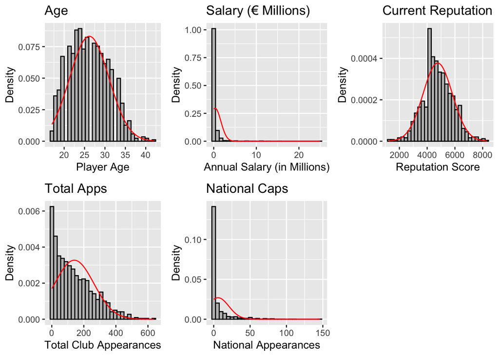

Figure 1. Histograms for continuous variables showing the distribution of Age, Salary, Current Reputation, Total Apps, and National Caps. Red lines represent the normal density curve.

```r
# Sample
set.seed(120)
wages_sample <- wages_cleaned[sample(nrow(wages_cleaned), 1000),] # Issues when rendering, solved by saving dataset after cleaning.

wages_sample$Salary_Millions <- wages_sample$Salary / 1e6 # Convert salary to millions
wages_sample$Reputation_Scaled <- wages_sample$`Current Reputation` / 1000


# 1. Age
hist_age <- ggplot(wages_sample, aes(x = Age)) +
  geom_histogram(aes(y = after_stat(density)), fill = "grey", colour = "black", bins = 30) +
  stat_function(fun = dnorm,
                args = list(mean = mean(wages_sample$Age, na.rm = TRUE),
                            sd = sd(wages_sample$Age, na.rm = TRUE)),
                colour = "red") +
  labs(title = "Age", x = "Player Age", y = "Density")

# 2. Salary in Millions
hist_salary <- ggplot(wages_sample, aes(x = Salary_Millions)) +
  geom_histogram(aes(y = after_stat(density)), fill = "grey", colour = "black", bins = 30) +
  stat_function(fun = dnorm,
                args = list(mean = mean(wages_sample$Salary_Millions, na.rm = TRUE),
                            sd = sd(wages_sample$Salary_Millions, na.rm = TRUE)),
                colour = "red") +
  labs(title = "Salary (€ Millions)", x = "Annual Salary (in Millions)", y = "Density")

# 3. Current Reputation
hist_cr <- ggplot(wages_sample, aes(x = `Current Reputation`)) +
  geom_histogram(aes(y = after_stat(density)), fill = "grey", colour = "black", bins = 30) +
  stat_function(fun = dnorm,
                args = list(mean = mean(wages_sample$`Current Reputation`, na.rm = TRUE),
                            sd = sd(wages_sample$`Current Reputation`, na.rm = TRUE)),
                colour = "red") +
  scale_y_continuous(labels = scales::comma) + # Improved Visualization
  labs(title = "Current Reputation", x = "Reputation Score", y = "Density")

# 4. Total Apps
hist_apps <- ggplot(wages_sample, aes(x = `Total Apps`)) +
  geom_histogram(aes(y = after_stat(density)), fill = "grey", colour = "black", bins = 30) +
  stat_function(fun = dnorm,
                args = list(mean = mean(wages_sample$`Total Apps`, na.rm = TRUE),
                            sd = sd(wages_sample$`Total Apps`, na.rm = TRUE)),
                colour = "red") +
  labs(title = "Total Apps", x = "Total Club Appearances", y = "Density")

# 5. National Caps
hist_caps <- ggplot(wages_sample, aes(x = `National Caps`)) +
  geom_histogram(aes(y = after_stat(density)), fill = "grey", colour = "black", bins = 30) +
  stat_function(fun = dnorm,
                args = list(mean = mean(wages_sample$`National Caps`, na.rm = TRUE),
                            sd = sd(wages_sample$`National Caps`, na.rm = TRUE)),
                colour = "red") +
  labs(title = "National Caps", x = "National Appearances", y = "Density")

# Combine in grid
grid.arrange(hist_age, hist_salary, hist_cr, hist_apps, hist_caps, ncol = 3)
```

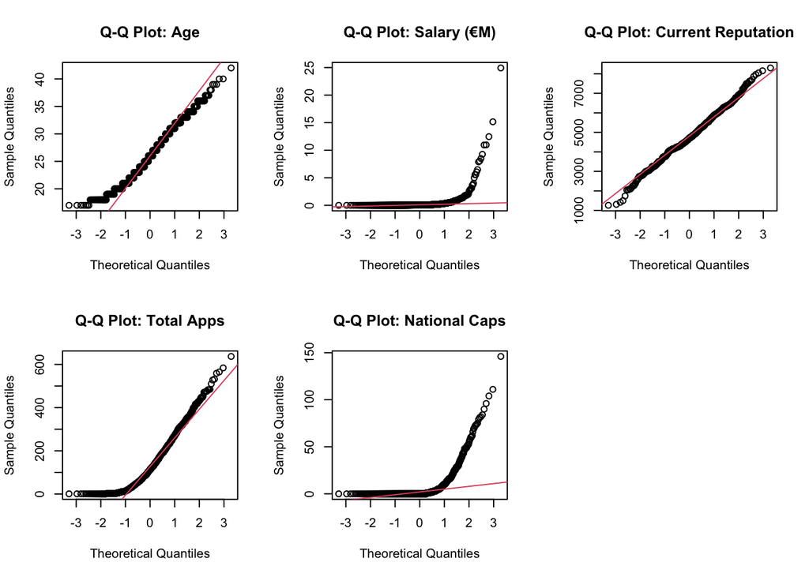

Figure 2. Q–Q plots for continuous variables assessing deviations from normality. Points deviating substantially from the red line indicate not normal distributions.

```r
par(mfrow = c(2, 3))

qqnorm(wages_sample$Age, main = "Q-Q Plot: Age"); qqline(wages_sample$Age, col = 2)
qqnorm(wages_sample$Salary_Millions, main = "Q-Q Plot: Salary (€M)"); qqline(wages_sample$Salary_Millions, col = 2)
qqnorm(wages_sample$`Current Reputation`, main = "Q-Q Plot: Current Reputation"); qqline(wages_sample$`Current Reputation`, col = 2)
qqnorm(wages_sample$`Total Apps`, main = "Q-Q Plot: Total Apps"); qqline(wages_sample$`Total Apps`, col = 2)
qqnorm(wages_sample$`National Caps`, main = "Q-Q Plot: National Caps"); qqline(wages_sample$`National Caps`, col = 2)

par(mfrow = c(1,1))  # reset layout
```

## 3. Analysis Approach

- For relationships between two continuous variables, **Spearman’s Rank-Order Correlation** was selected, as it does not assume normality. (Both variables are continuous, but normality in salary is not met)
- When comparing a continuous variable across a **binary categorical variable**, the **Mann–Whitney U test** was applied. (Comparing a continuous non-normal variable across two groups.)
- To compare a continuous variable across **multiple groups**, a **Kruskal–Wallis test** was used. (Continuous non-normal variable compared across 3+ groups, since leagues are multi-category nominal).
- Finally, relationships between two **nominal variables** were examined using a **Chi-square test of independence**. (For two nominal variables)

Reporting both statistical significance and effect size provides a comprehensive understanding of the magnitude and practical importance of observed effects.

Table 3. Overview of Planned Statistical Analyses

| **Analysis Focus** | **Test Type** |
| --- | --- |
| Salary vs Current Reputation | Spearman’s Rank Correlation |
| Salary vs EU Player | Mann–Whitney U Test |
| Salary vs League | Kruskal–Wallis H Test |
| EU Player vs League | Chi-square Test of Independence |

## 4. Results

### 4.1 Relationship between Salary and Current *Reputation*

H0: There is no relationship between a player’s Current Reputation and their Salary.

H1: There is a relationship between a player’s Current Reputation and their Salary.

The association between players’ Current Reputation and Salary was examined using a Spearman’s rank order correlation, as Salary was not normally distributed. The results indicated a strong positive relationship, r = 0.84, n = 35,161, p < .001 Results This suggests that higher reputation scores are strongly associated with higher salaries.

Therefore, there is sufficient evidence to reject the null hypothesis in favour of the alternative. In practical terms, players with greater reputation values tend to earn substantially higher salaries, highlighting the strong link between perceived skill level and financial reward within professional football.

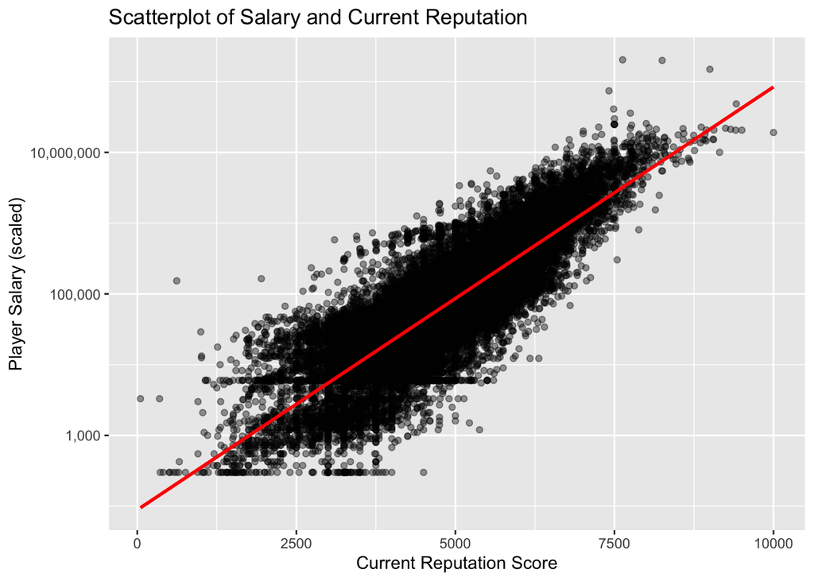

Figure 3. Scatterplot showing the relationship between Current Reputation and Salary among players

```r
#To avoid extreme outliers I used a log sclale on the y-axis to reduce the exteme salary outliers
scatter <- ggplot(wages_cleaned, aes(x = `Current Reputation`, y = Salary)) +
  geom_point(alpha = 0.4) +
  geom_smooth(method = "lm", colour = "red", se = FALSE) +
  scale_y_log10(labels = scales::comma) +
  labs(
    x = "Current Reputation Score",
    y = "Player Salary (scaled)",
    title = "Scatterplot of Salary and Current Reputation"
  )

scatter
```

### 4.2 Difference in Salary between EU and non-EU players

H0: There is no difference in Salary between EU and Non-EU players. H1: There is a difference in Salary between EU and Non-EU players.

A Mann–Whitney U test was performed to examine salary differences between EU and Non-EU players. The results indicated a statistically significant difference W = 135,551,244, p < .001 Results suggesting that the two groups differ in their salary distributions.

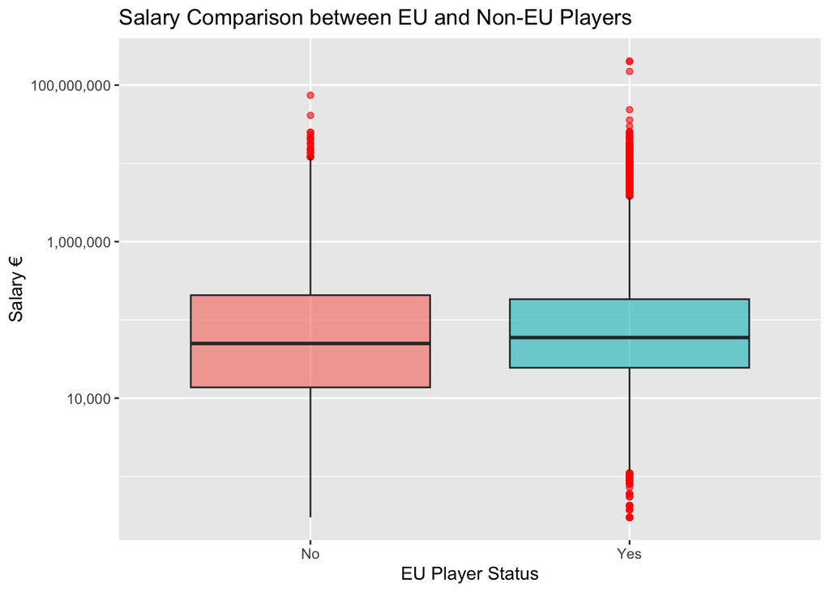

Figure 5. Boxplot comparing salaries between EU and Non-EU players

```r
# The log transformation was applied to improve visualization due to the highly skewed salary distribution.

ggplot(wages_cleaned, aes(x = `EU Player`, y = Salary, fill = `EU Player`)) +
  geom_boxplot(outlier.color = "red", alpha = 0.6) +
  scale_y_log10(labels = scales::comma) +
  labs(
    title = "Salary Comparison between EU and Non-EU Players",
    x = "EU Player Status",
    y = "Salary €"
  ) +

  theme(legend.position = "none")
```

### 4.3 Difference in Salary across different Leagues

H0: Average salaries are not different across football leagues. H1: Average salaries are different across football leagues.

A Kruskal–Wallis H test was conducted to compare player salaries across five football leagues: Premier League, LaLiga EA SPORTS, Bundesliga, Ligue 1 Uber Eats, and Other Leagues. This non-parametric test was chosen because salary distributions were highly skewed and did not meet the assumptions of normality required for ANOVA.

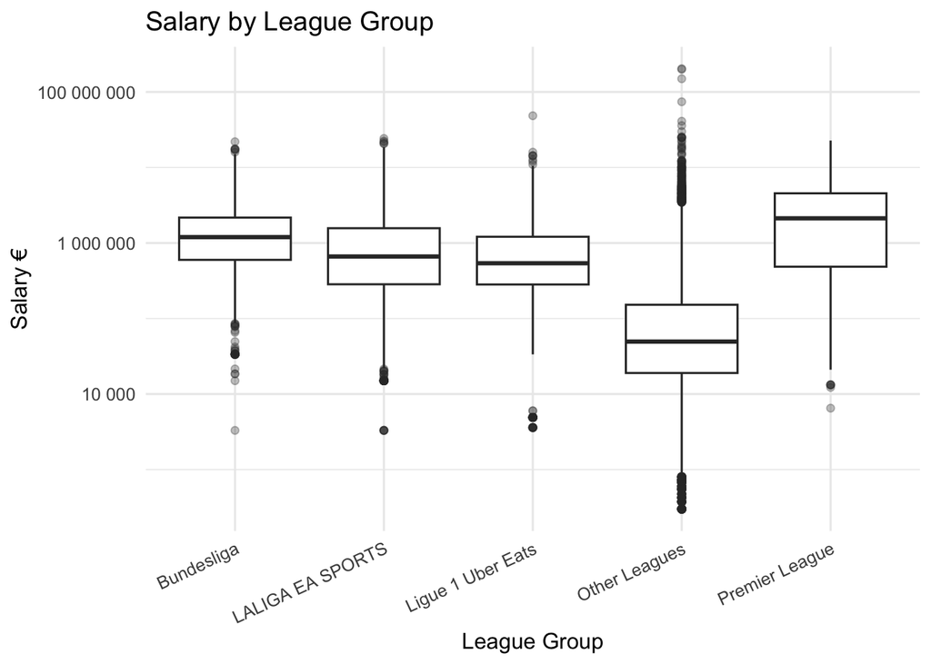

Boxplot of player salaries by football league

```r
# The log transformation was applied to improve visualization due to the highly skewed salary distribution.

ggplot(wages_cleaned, aes(x = League, y = Salary)) +
  geom_boxplot(outlier.alpha = 0.3) +
  scale_y_log10(labels = scales::label_number()) +
  labs(
    title = "Salary by League Group",
    x = "League Group",
    y = "Salary €"
  ) +
  theme_minimal(base_size = 12) +
  theme(axis.text.x = element_text(angle = 25, hjust = 1))
```

### 4.4 Relationship between Nationality region and League

H0: EU status and league are unrelated H1: EU status and league are related.

A Chi-square test of independence was conducted to examine the relationship between a player’s EU membership status (“Yes” or “No”) and the league in which they play (Premier League, LaLiga EA SPORTS, Bundesliga, Ligue 1 Uber Eats, and Other Leagues). The test revealed a statistically significant association between EU status and league, χ²(4, N = 35,161) = 577.50, p < .001. This indicates that the proportion of EU and non-EU players differs significantly across leagues.

Inspection of the standardised residuals presented in the Chi-square Test of Independence Table suggests that non-EU players are overrepresented in the Premier League and underrepresented in most European leagues, while EU players are more common in LaLiga and the Bundesliga. Therefore, the null hypothesis is rejected, providing evidence that EU status and league are associated.

## 5. Discussion

The aim of this analysis was to examine factors associated with professional football players’ salaries, focusing on current reputation, EU membership, and league affiliation. Across all four analyses, statistically significant relationships were found, revealing consistent patterns in how player attributes and league context influence earnings.

The strong positive association between reputation and salary indicates that higher-reputation players earn more, reflecting how performance history and market value drive wages in professional football. Similarly, EU membership was significantly related to salary, suggesting that labour mobility and transfer regulations within Europe may advantage EU players in securing higher-paying contracts.

## 6. Conclusion

This analysis examined whether player reputation, EU membership, and league affiliation were associated with differences in salary among professional football players. The results indicated significant relationships across all analyses: higher-reputation players earned greater salaries, EU membership was linked to salary differences, and wages varied notably across leagues, with the Premier League showing the highest earnings. In addition, EU status and league were found to be associated, reflecting distinct patterns in player distribution across European and non-European competitions.

Overall, these findings highlight how both player characteristics and structural factors within professional football contribute to salary disparities. While statistical significance was influenced by the large sample size, the observed trends align with real-world economic and regulatory dynamics of the sport. Future research could expand on this work by incorporating variables such as player position, experience, and club revenue to better explain salary variation and deepen understanding of wage inequality in global football.

## 7. References

Yash. (2024). Football Player Salaries Dataset. Retrieved from www.kaggle.com website: https://www.kaggle.com/datasets/ultimus/football-salaries-dataset

Curran, Patrick J., Stephen G. West, and John F. Finch. (1996). “The robustness of test statistics to nonnormality and specification error in confirmatory factor analysis.”

Field, A., Field Z. & Miles J.(2012). Discovering statistics using IBM SPSS statistics. Sage publications limited.

# Appendix

## 1. Cleaning and fix Dataset

### 1.1. Dropping columns

```r
# Dropping columns that are not useful
wages <- wages |>
  select(  -name, -club, -position, -based, -begins, -expires, -last.club, -last.trans..fee
  )
# Check remaining variables
colnames(wages)
```

```
[1] "division"    "nat"         "eu.national" "caps"        "at.apps"
[6] "age"         "cr"          "salary"
```

### 1.2. Renaming columns

```r
# Renaming columns for clarity
wages <- wages |>
  dplyr::rename(
    League            = division,
    Nationality       = nat,
    `EU Player`       = eu.national,
    `National Caps`   = caps,
    `Total Apps`      = `at.apps`,
    Age               = age,
    `Current Reputation` = cr,
    Salary            = salary
  )

colnames(wages)
```

```
[1] "League"             "Nationality"        "EU Player"
[4] "National Caps"      "Total Apps"         "Age"
[7] "Current Reputation" "Salary"
```

### 1.3. Omitting columns of useful columns

```r
#removing the rows of our valid columns, since wouldn't contribute to the analyses
wages <- na.omit(wages)
colSums(is.na(wages))
```

```
            League        Nationality          EU Player      National Caps
                 0                  0                  0                  0
        Total Apps                Age Current Reputation             Salary
                 0                  0                  0                  0
```

### 1.4. Final Pre-Processing: Cleaning Symbols, Spaces, and Converting to Factors

```r
# I had 754 different leagues, so in order to correct this I scaled down to the most important ones and separate the rest as "others"
top_leagues <- c("Premier League", "LALIGA EA SPORTS", "Bundesliga",
                 "Serie A", "Ligue 1 Uber Eats", "Rosh Saudi League")

# Recode leagues into groups
wages$League <- ifelse(wages$League %in% top_leagues,
                            wages$League,
                            "Other Leagues")


# Removing extra symbols and spaces, and ensuring data behaves as intended by converting variables to factors

wages$League <- as.factor(str_trim(wages$League))

wages$Nationality <- as.factor(wages$Nationality)

wages$`EU Player` <- factor(str_trim(wages$`EU Player`), levels = c("No", "Yes")) # Convert to binary

wages$`National Caps` <- as.numeric(wages$`National Caps`) # Convert National Cap  to numeric
wages$`Total Apps` <- as.numeric(str_replace_all(wages$`Total Apps`, "[^0-9]", "")) # Clean and convert total apps to numeric

wages$`Current Reputation` <- as.numeric(str_replace_all(wages$`Current Reputation`, ",", "")) # Clean and convert Current reputation to numeric

wages$Salary <- as.numeric(str_replace_all(wages$Salary, "[^0-9]", ""))# Clean and convert salary to numeric

# Strucure and summary
str(wages)
```

```
'data.frame':   35161 obs. of  8 variables:
 $ League            : Factor w/ 5 levels "Bundesliga","LALIGA EA SPORTS",..: 4 4 4 4 3 4 4 4 4 4 ...
 $ Nationality       : Factor w/ 216 levels "AFG","AIA","ALB",..: 156 67 29 59 67 166 47 166 67 177 ...
 $ EU Player         : Factor w/ 2 levels "No","Yes": 2 2 2 1 2 1 2 2 2 1 ...
 $ National Caps     : num  200 97 124 0 70 93 87 70 53 81 ...
 $ Total Apps        : num  673 555 340 245 221 377 392 367 361 378 ...
 $ Age               : num  38 35 31 25 24 31 30 32 32 28 ...
 $ Current Reputation: num  7629 8250 9000 7414 9415 ...
 $ Salary            : num  2.03e+08 1.99e+08 1.50e+08 7.42e+07 4.85e+07 ...
 - attr(*, "na.action")= 'omit' Named int [1:5630] 3553 4369 4543 4724 4800 4904 5077 5085 5104 5105 ...
  ..- attr(*, "names")= chr [1:5630] "3553" "4369" "4543" "4724" ...
```

```r
# Save cleaned dataset
saveRDS(wages, "wages_cleaned.rds")
wages_cleaned <- readRDS("wages_cleaned.rds")

head(wages_cleaned, 2)
```

```
         League Nationality EU Player National Caps Total Apps Age
1 Other Leagues         POR       Yes           200        673  38
2 Other Leagues         FRA       Yes            97        555  35
  Current Reputation    Salary
1               7629 203478000
2               8250 199452000
```

### 1.5. Normality Assessment for Continuous Variables

```r
# Showing mean, sd, skew, and kurtosis per variable
# Age
print("AGE")
```

```
[1] "AGE"
```

```r
print(summary(wages_sample$Age))
```

```
   Min. 1st Qu.  Median    Mean 3rd Qu.    Max.
  17.00   22.00   26.00   26.16   30.00   42.00
```

```r
print(paste("SD:", round(sd(wages_sample$Age, na.rm = TRUE), 2)))
```

```
[1] "SD: 4.79"
```

```r
print(semTools::skew(wages_sample$Age))
```

```
skew (g1)        se         z         p
    0.258     0.077     3.337     0.001
```

```r
print(semTools::kurtosis(wages_sample$Age))
```

```
Excess Kur (g2)              se               z               p
         -0.613           0.155          -3.955           0.000
```

```r
# Salary already in Millions
print("SALARY")
```

```
[1] "SALARY"
```

```r
print(summary(wages_sample$Salary_Millions))
```

```
    Min.  1st Qu.   Median     Mean  3rd Qu.     Max.
 0.00030  0.01925  0.04875  0.33135  0.16400 24.93100
```

```r
print(paste("SD:", round(sd(wages_sample$Salary_Millions, na.rm = TRUE), 2)))
```

```
[1] "SD: 1.35"
```

```r
print(semTools::skew(wages_sample$Salary_Millions))
```

```
skew (g1)        se         z         p
   10.532     0.077   135.967     0.000
```

```r
print(semTools::kurtosis(wages_sample$Salary_Millions))
```

```
Excess Kur (g2)              se               z               p
        145.981           0.155         942.302           0.000
```

```r
# Current Reputation
print("CURRENT REPUTATION")
```

```
[1] "CURRENT REPUTATION"
```

```r
print(summary(wages_sample$`Current Reputation`))
```

```
   Min. 1st Qu.  Median    Mean 3rd Qu.    Max.
   1262    4150    4700    4760    5476    8300
```

```r
print(paste("SD:", round(sd(wages_sample$`Current Reputation`, na.rm = TRUE), 2)))
```

```
[1] "SD: 1056.71"
```

```r
print(semTools::skew(wages_sample$`Current Reputation`))
```

```
skew (g1)        se         z         p
    0.092     0.077     1.191     0.234
```

```r
print(semTools::kurtosis(wages_sample$`Current Reputation`))
```

```
Excess Kur (g2)              se               z               p
          0.338           0.155           2.183           0.029
```

```r
# Total Apps
print("TOTAL APPS")
```

```
[1] "TOTAL APPS"
```

```r
print(summary(wages_sample$`Total Apps`))
```

```
   Min. 1st Qu.  Median    Mean 3rd Qu.    Max.
    1.0    38.0   113.0   140.6   217.0   637.0
```

```r
print(paste("SD:", round(sd(wages_sample$`Total Apps`, na.rm = TRUE), 2)))
```

```
[1] "SD: 121.9"
```

```r
print(semTools::skew(wages_sample$`Total Apps`))
```

```
skew (g1)        se         z         p
    0.925     0.077    11.937     0.000
```

```r
print(semTools::kurtosis(wages_sample$`Total Apps`))
```

```
Excess Kur (g2)              se               z               p
          0.358           0.155           2.313           0.021
```

```r
# National Caps
print("NATIONAL CAPS")
```

```
[1] "NATIONAL CAPS"
```

```r
print(summary(wages_sample$`National Caps`))
```

```
   Min. 1st Qu.  Median    Mean 3rd Qu.    Max.
  0.000   0.000   0.000   5.956   4.000 146.000
```

```r
print(paste("SD:", round(sd(wages_sample$`National Caps`, na.rm = TRUE), 2)))
```

```
[1] "SD: 14.79"
```

```r
print(semTools::skew(wages_sample$`National Caps`))
```

```
skew (g1)        se         z         p
    4.010     0.077    51.764     0.000
```

```r
print(semTools::kurtosis(wages_sample$`National Caps`))
```

```
Excess Kur (g2)              se               z               p
         20.350           0.155         131.359           0.000
```

## 2. Statistical Tests

### 2.1. Spearman’s Rank-Order Correlation (Salary and Current Reputation)

```r
cor_test <- cor.test( wages_cleaned$Salary, wages_cleaned$`Current Reputation`, method = "spearman", exact = FALSE
)
cor_test
```

```
    Spearman's rank correlation rho

data:  wages_cleaned$Salary and wages_cleaned$`Current Reputation`
S = 1.1446e+12, p-value < 2.2e-16
alternative hypothesis: true rho is not equal to 0
sample estimates:
     rho
0.842019
```

### 2.2. Mann–Whitney U Test (Salary by EU vs Non-EU Players)

```r
# Mann–Whitney U test: comparing salaries between EU and Non-EU players
mw_test <- wilcox.test(Salary ~ `EU Player`, data = wages_cleaned, exact = FALSE)

mw_test
```

```
    Wilcoxon rank sum test with continuity correction

data:  Salary by EU Player
W = 135551244, p-value < 2.2e-16
alternative hypothesis: true location shift is not equal to 0
```

```r
# Extract key values for report
W <- mw_test$statistic
pval <- format.pval(mw_test$p.value, digits = 3)
cat("W =", W, ", p-value =", pval)
```

```
W = 135551244 , p-value = <2e-16
```

### 2.3. Kruskal–Wallis Test (Salary Across Leagues)

```r
# Check distribution
table(wages_cleaned$League)
```

```
       Bundesliga  LALIGA EA SPORTS Ligue 1 Uber Eats     Other Leagues
              516               545               476             32908
   Premier League
              716
```

```r
# Run Kruskal–Wallis again
kruskal_test <- kruskal.test(Salary ~ League, data = wages_cleaned)
kruskal_test
```

```
    Kruskal-Wallis rank sum test

data:  Salary by League
Kruskal-Wallis chi-squared = 3515.6, df = 4, p-value < 2.2e-16
```

### 2.4. Chi-Square Test of Independence (Nationality Region and League)

```r
# Remove rows with missing values just in case
wages_c <- wages %>%
  filter(!is.na(`EU Player`) & !is.na(League))

# Run SPSS-style Chi-square CrossTable
gmodels::CrossTable(
    wages_c$League,

  wages_c$`EU Player`,
  chisq = TRUE,        # Chi-square test only
  expected = TRUE,     # Show expected values
  sresid = TRUE,       # Show standardized residuals
  format = "SPSS"      # SPSS-style output
)
```

```
   Cell Contents
|-------------------------|
|                   Count |
|         Expected Values |
| Chi-square contribution |
|             Row Percent |
|          Column Percent |
|           Total Percent |
|            Std Residual |
|-------------------------|

Total Observations in Table:  35161

                  | wages_c$`EU Player`
   wages_c$League |       No  |      Yes  | Row Total |
------------------|-----------|-----------|-----------|
       Bundesliga |       48  |      468  |      516  |
                  |  212.675  |  303.325  |           |
                  |  127.509  |   89.402  |           |
                  |    9.302% |   90.698% |    1.468% |
                  |    0.331% |    2.264% |           |
                  |    0.137% |    1.331% |           |
                  |  -11.292  |    9.455  |           |
------------------|-----------|-----------|-----------|
 LALIGA EA SPORTS |       68  |      477  |      545  |
                  |  224.628  |  320.372  |           |
                  |  109.213  |   76.574  |           |
                  |   12.477% |   87.523% |    1.550% |
                  |    0.469% |    2.308% |           |
                  |    0.193% |    1.357% |           |
                  |  -10.451  |    8.751  |           |
------------------|-----------|-----------|-----------|
Ligue 1 Uber Eats |       88  |      388  |      476  |
                  |  196.189  |  279.811  |           |
                  |   59.661  |   41.831  |           |
                  |   18.487% |   81.513% |    1.354% |
                  |    0.607% |    1.877% |           |
                  |    0.250% |    1.103% |           |
                  |   -7.724  |    6.468  |           |
------------------|-----------|-----------|-----------|
```

[output cut: 16 more lines]

```
     Column Total |    14492  |    20669  |    35161  |
                  |   41.216% |   58.784% |           |
------------------|-----------|-----------|-----------|


Statistics for All Table Factors


Pearson's Chi-squared test
------------------------------------------------------------
Chi^2 =  577.4982     d.f. =  4     p =  1.147843e-123



       Minimum expected frequency: 196.1887
```